# Demand Side I: Labor Markets, Productivity, and Automation

POLISCI 158 · AI & Politics · Session 2 · Mon, Sep 28, 2026

Simone Paci

## Roadmap

1. What the newest evidence says
   - Read the newest evidence on AI and jobs, and its limits
   - Explain why the adjustment runs through hiring, not firing
2. The political economy of labor-market shocks
   - Compare concentrated and economy-wide shocks
   - Use the China shock to predict when AI’s turns political
3. Your project, with AI
   - Map the final-project workflows onto the quarter

# Part I: What the newest evidence says

## Canaries in the coal mine?

- Brynjolfsson, Chandar & Chen, Stanford Digital Economy Lab
- ADP payroll: millions of U.S. workers, to June 2026
- First version August 2025; revised August 2026
- Six descriptive facts, not causal estimates

Source: Brynjolfsson, Chandar & Chen, “Canaries in the Coal Mine? Six Facts about the Recent Employment Effects of Artificial Intelligence,” August 2026 revision, digitaleconomy.stanford.edu.

## Fact 1: no economy-wide displacement

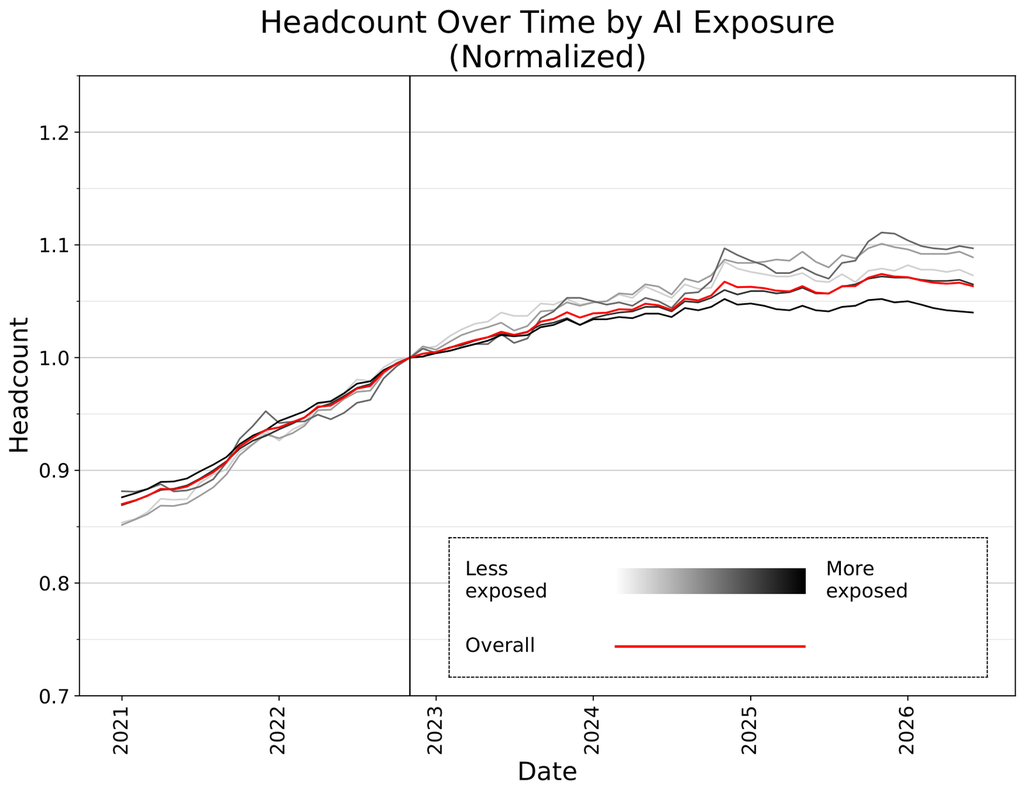

Nov 2022 to Jun 2026: ADP sample about +6%, most-exposed quintile about +4%. Figure 1, Brynjolfsson, Chandar & Chen (Aug 2026), ADP data; exposure from Eloundou et al. (2024).

## Fact 2: young workers in exposed jobs

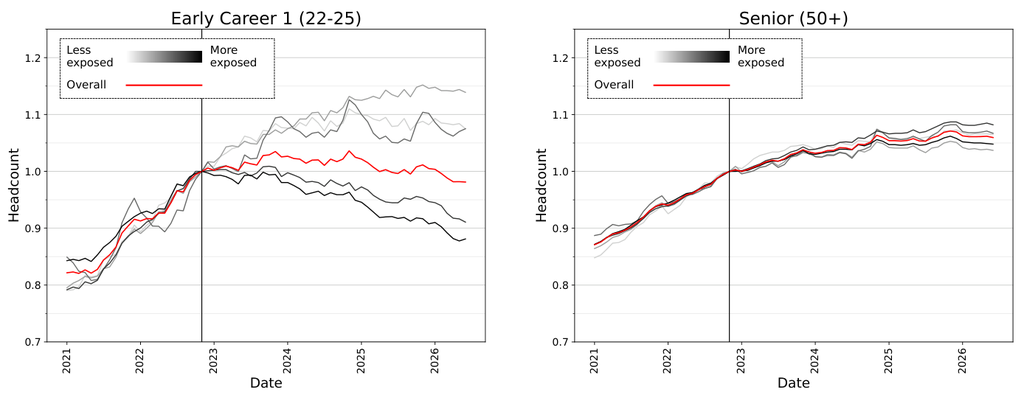

Ages 22–25, two most-exposed quintiles: about −11% (Nov 2022 to Jun 2026); three least-exposed: about +10%. That is 19% below where they would be had they kept pace. Figure 3 (two of six panels), Brynjolfsson, Chandar & Chen (Aug 2026).

## Facts 3–4: widening, through hiring

- **Wider:** 15% (Jul 2025 data) → 19% (Jun 2026 data)
- **Not more firing:** young workers’ separations fell, as much or more in exposed jobs
- **Less hiring:** the hiring gap opened after 2022
- *A job that was never offered*

Source: Brynjolfsson, Chandar & Chen (Aug 2026), Sections 2.3–2.4.

## Fact 5: automation vs. complementarity

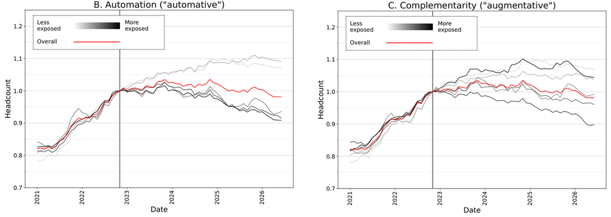

- Where AI **automates** tasks: young workers’ employment falls
- Where AI **complements** workers: no clear ordering

Ages 22–25. Figure 5, panels B–C, Brynjolfsson, Chandar & Chen (Aug 2026); usage measures from the Anthropic Economic Index (Handa et al., 2025).

## Fact 6 and the caveats

**Fact 6:** adjustment through jobs, not base pay

**Caveats**

- Descriptive, not causal
- Some divergence predates ChatGPT (COVID era)
- Weaker once education is controlled
- Stronger in ADP than in national surveys

Source: Brynjolfsson, Chandar & Chen (Aug 2026), abstract and Sections 2.6, 4–5.

## Tracking it live: AI Economic Indicators

- **Canaries Dashboard**: monthly employment by age and AI exposure (with ADP Research)
- **Transformation Tracker**: 12 macro indicators: 2 strong, 4 mild, 6 neutral
- Also on the hub: **Adoption Monitor** and **GDP-B**

Source: Stanford Digital Economy Lab, AI Economic Indicators, digitaleconomy.stanford.edu/project/indicators; Canaries Dashboard and Transformation Tracker last updated September 23, 2026.

## Tracker: no statewide surge

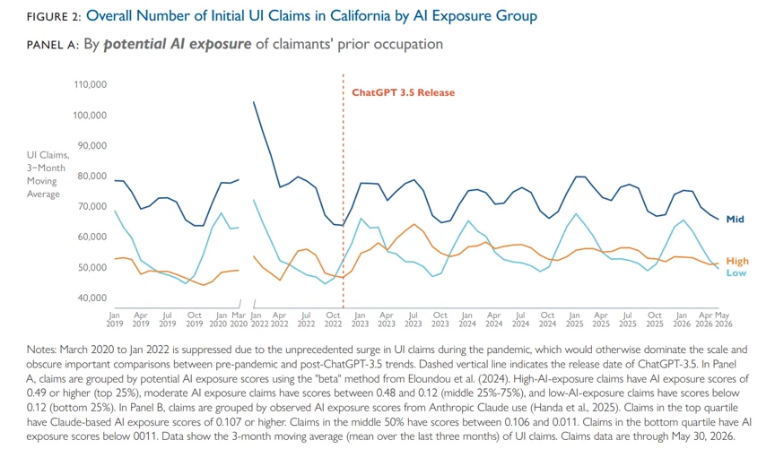

Figure 2, Hyman, von Wachter, Herrera, Moghadam, Morris, Motghare & Segal, California Policy Lab (June 2026). Claims through May 2026.

## Tracker: college-educated, high-exposure claims up

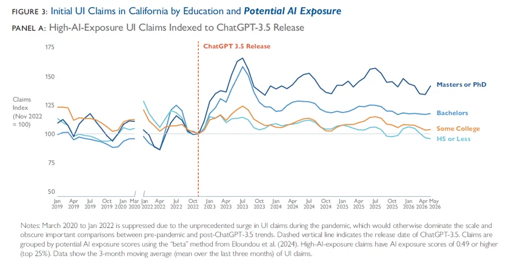

Figure 3, California Policy Lab (June 2026). Claims indexed to Nov 2022 = 100; exposure from Eloundou et al. (2024).

## Tracker: the Bay Area

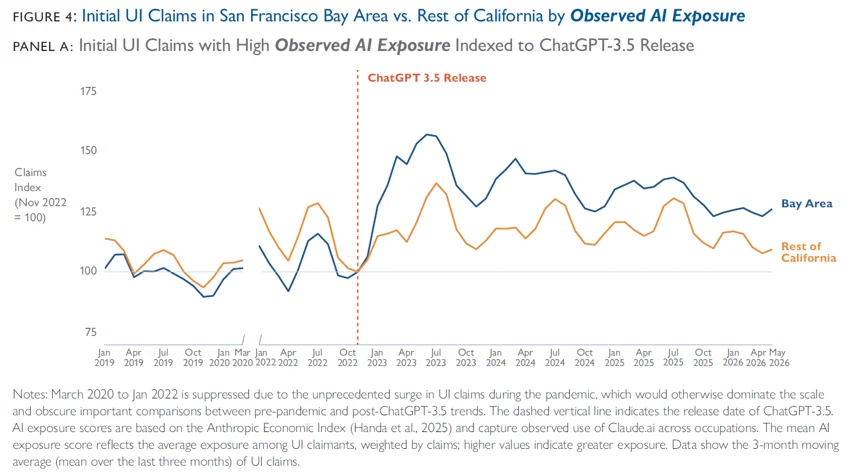

Figure 4, California Policy Lab (June 2026). Observed exposure from the Anthropic Economic Index (Handa et al., 2025).

## So who notices?

A layoff has a victim, a date, and a headline.

A job that was never offered has none of these.

Keep this in mind for Part II.

# Part II: The political economy of labor-market shocks

## Your exposure is your politics

- Starting assumption: pure material self-interest
- Not exposed → lower prices → happy
- Exposed → lost job or wages → unhappy
- The standard recipe for trade and globalization
- Easy, right?

Scheve & Slaughter (2001), “What Determines Individual Trade-Policy Preferences?”, *Journal of International Economics*.

## What does exposure mean?

**Displacement / substitution**

- Jobs fully automated → little need for human labor → fewer jobs, lower wages

**Reinstatement / augmentation**

- Jobs partly automated → more need for skilled labor → more jobs, higher productivity and wages

## Measuring exposure: easier said…

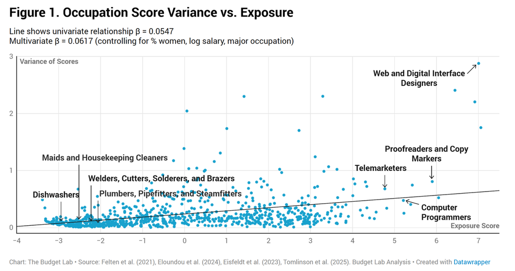

Indexes disagree more about the most exposed jobs.

Figure 1, Gimbel, Kendall & Kulsakdinun, “Labor Market AI Exposure: What Do We Know?”, The Budget Lab at Yale (Feb 19, 2026).

## Okay, then maybe we measure automation?

[figure not shown]

[figure not shown]

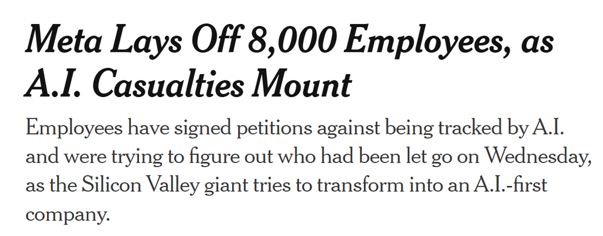

Headlines as shown in the 157 deck (summer 2026): Reuters (Jun 22, 2026); Wall Street Journal (May 5, 2026); New York Times.

## But can we trust these announcements?

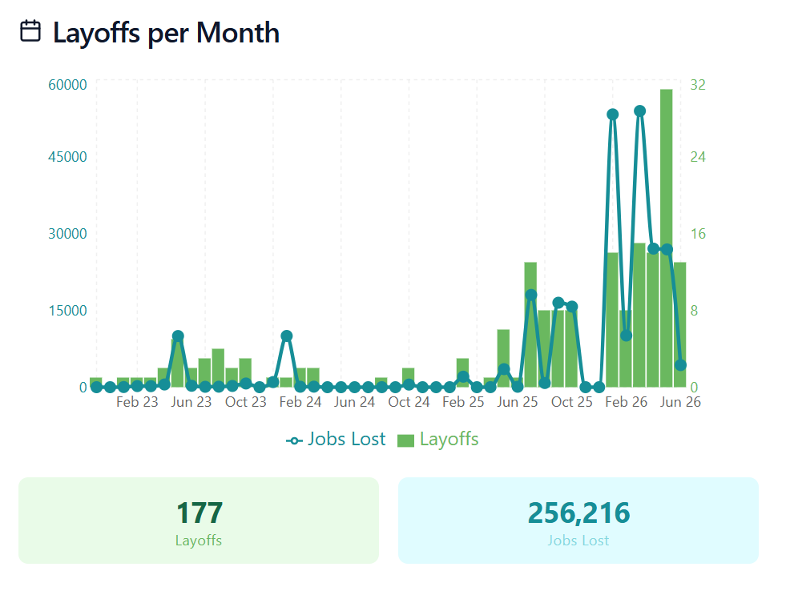

JobsLost.ai (jobslost.ai), screenshot as used in 157 (mid-2026). Compiled from company announcements and news reports; on Sep 27, 2026 it listed 203 layoffs and 265,086 jobs.

## On the other side: will productivity pay off?

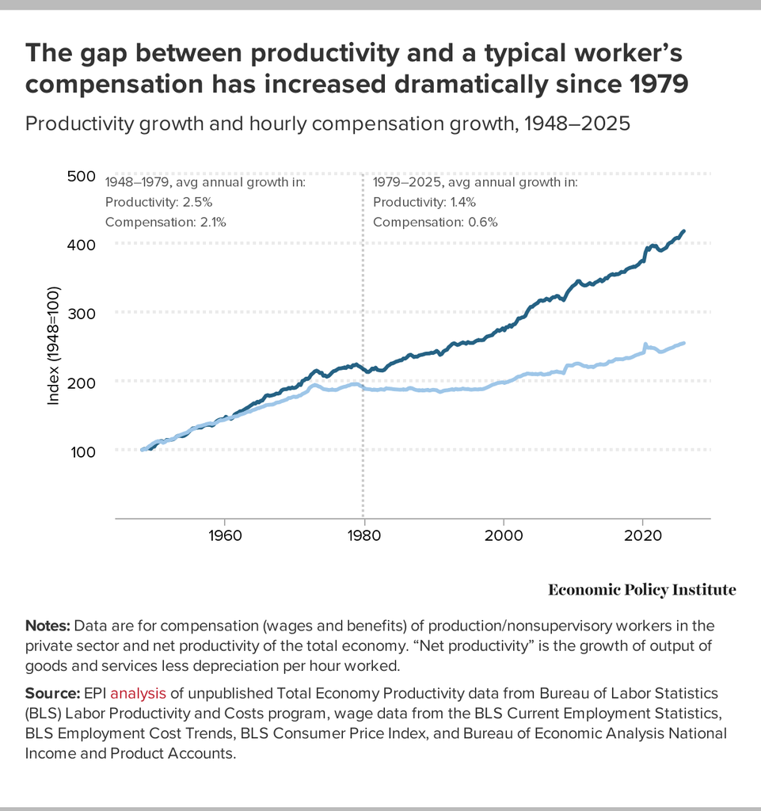

Economic Policy Institute, “The Productivity–Pay Gap” (chart as captured in 157, data to 2025; page updated Sep 14, 2026 with data to 2026). epi.org/productivity-pay-gap

## When does politics react?

- Preferences alone don’t pass policy
- Mobilization → accountability and responsiveness
- Two shapes of shock:
  - Small and concentrated
  - Large and economy-wide

## TEAM DEBATE

When do we expect a stronger political response:  
smaller concentrated shocks or larger economy-wide shocks?

Left half: **concentrated** · Right half: **economy-wide** · sides are assigned  
Pods of 3–4 · 4 minutes · one mechanism (who mobilizes, through which institution) + one example

## The China shock: 2 million jobs in 12 years

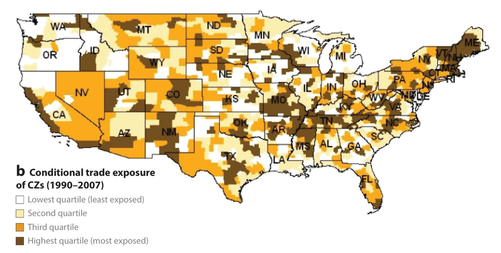

Figure 6b, Autor, Dorn & Hanson (2016), “The China Shock,” *Annual Review of Economics*. Job losses 1999–2011 (2.0 million economy-wide, input-output linkages) from Acemoglu et al. (2016) as summarized there.

## The China shock: little compensation

Per $1,000 of import exposure per worker:

- −$549 household wage and salary income per working-age adult
- +$58 government transfers per person
- only $3.65 of it via UI and TAA

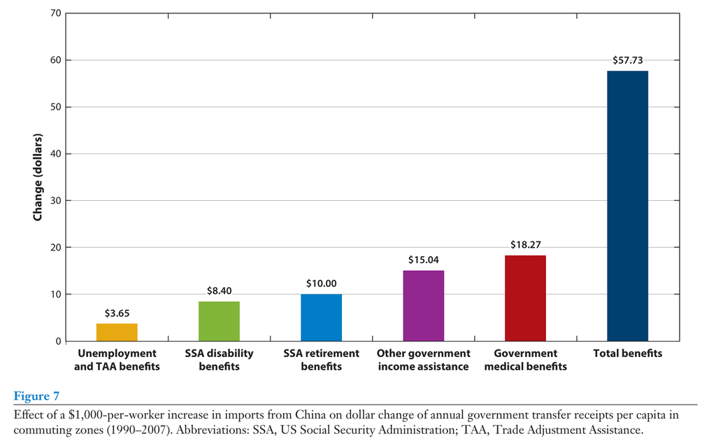

Autor, Dorn & Hanson (2016), Table 4 cols. 7–8 and Figure 7; annual, commuting zones 1990–2007.

## What does it take? Mass sacrifice = mass compensation?

[figure not shown]

[figure not shown]

Tax Policy Center, Historical Highest Marginal Income Tax Rates (1913–2023); Scheve & Stasavage (2016), *Taxing the Rich*, Princeton University Press.

## What about organized labor?

[figure not shown]

Writers Guild of America West, “Artificial Intelligence: Know Your Rights” (updated Dec 18, 2025). wga.org

## What about organized labor? Approval is high

[figure not shown]

Gallup, Megan Brenan, “Labor Union Approval Relatively Steady at 68% in U.S.” (Aug 28, 2025).

## What about organized labor? Membership is low

[figure not shown]

Figure 1, Bauer & Cole, “Six Facts About Union Density in the United States,” The Hamilton Project (May 22, 2026).

# Part III: Your project, with AI

## How it fits the quarter

1. **Proposal** · Oct 11 · workflows 01–03
2. **Implementation milestone** · Nov 15 · 04–05
3. **Panel presentation** · Nov 30 / Dec 2 · 06
4. **Final submission** · finals week · 07

Practice it in section. Find it in the **final project guide**.

## See you next class

# Backup slides

## California’s AI-related job loss tracker

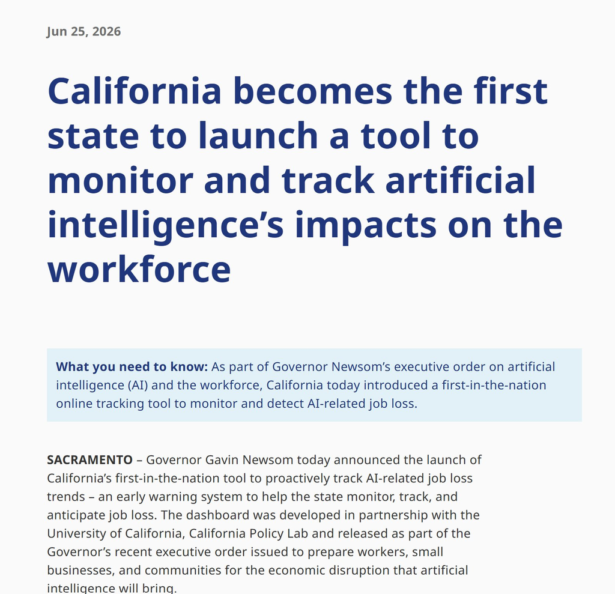

Office of the Governor of California, press release, June 25, 2026 (as shown in 157). Tracker built by the California Policy Lab with the Employment Development Department.

## Why a workflow with AI in it?

- This course **studies** AI and **uses** it
- Use AI extensively for applied work
- Keep the words, understanding and decisions yours
- Disclose what AI did

## How the package is built

**The files**

- **1 overview**: the project, milestones, grading
- **7 workflows**: one per stage
- **4 docs**: AI use, peer review, rubrics, proposal template

**Every step is tagged**

- **You**: your own work
- **With AI**: a ready-made prompt
- **You decide**: the choice is yours

*A suggestion, not a requirement.*